# Part II - Factors Affecting the Borrowers APR

## by Joseph Eze

## Investigation Overview

> I want to investigate variables that affect the borrowers interest annual rate (%), variables of interest are the Occupation, EmploymentStatus, LoanStatus, IncomeRange, ProperRating (Alpha), StatedMonthlyIncome and the MonthlyLoanPayment.

## Dataset Overview

> This is a data set from Prosper, which is America’s first marketplace lending platform, with over $9 billion in funded loans. This data set contains 113,937 loans with 81 variables on each loan, including loan amount, borrower rate (or interest rate), current loan status, borrower income, and many others. This data dictionary explains the variables in the data set.

## Distribution of Borrower APR

> The Borrower APR plot is multi-modal with the first peak before 0.1% and the highest peak around 0.3% and 0.37%

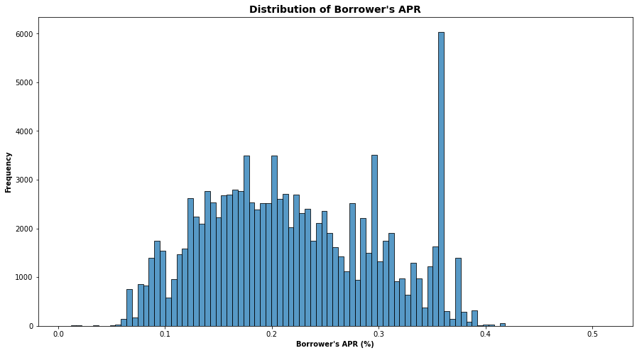

## Distribution of Prosper Rating (Alpha)

> We can see that most of the loan post July 2009 has the credit rating of C, with the B ratings following behind.

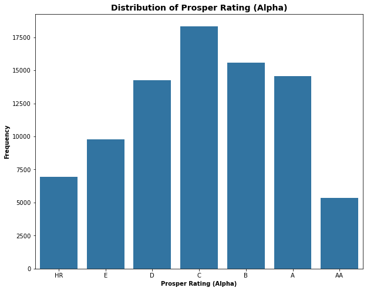

## Distribution of Occupation

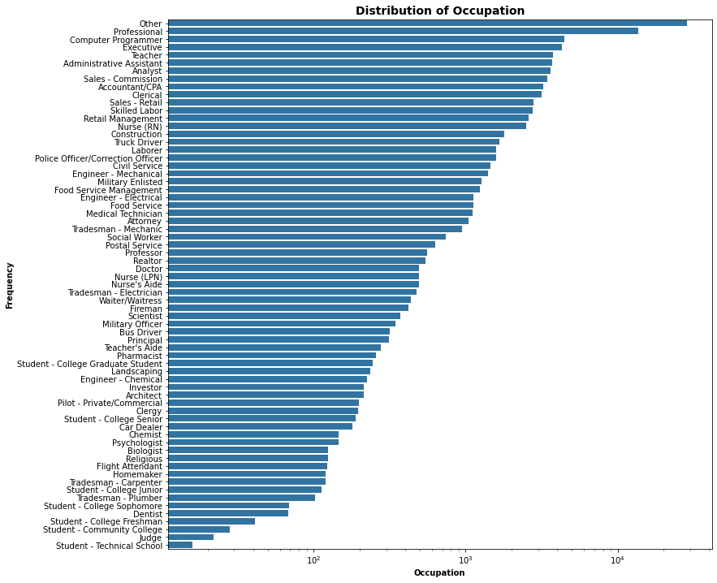

## Relationship between the Numerical Variable of Interest

> We can see a high positive correlation between our variable of interest (BorrowerAPR) with the BorrowerRate and the EstimatedEffectiveYield, another obeservation is the positive correlation between the LoanOriginalAmount and the MonthlyLoanPayment.

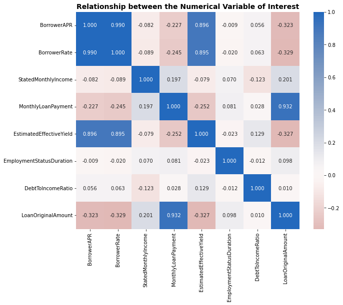

## Relationship between the ProsperRating (Alpha), BorrowerAPR and IncomeRange

> This shows the HR rating has a higher amount of BorrowerAPR, AA rating has the least amount, the plot also show a negative correlation, the higher the ratings, the lower the BorrowerAPR.

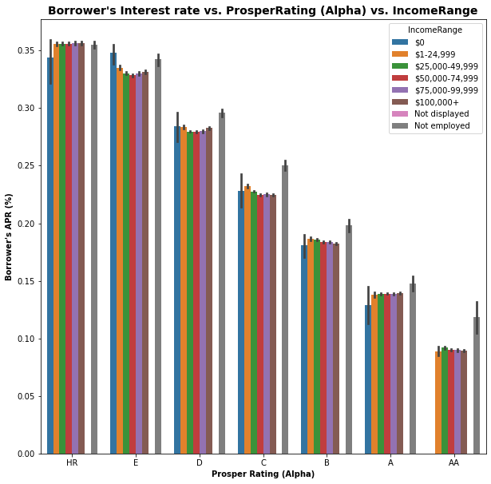